# Project - Model for predict Barbell Lifts perform

Joaquín Soliño

03-07-2021

## Summary

Human Activity Recognition - HAR - has emerged in the 2000’s and is gaining increasing attention by the pervasive computing research community.

Today, devices such as Jawbone Up, Nike FuelBand, and Fitbit allow to collect a large amount of data about personal activity. The most regular use of this data is to mesaure how much of a particular activity is done. In fact, it rarely is used to quantify how well is done

We will use data from accelerometers on the belt, forearm, arm, and dumbell of 6 participants. They were asked to perform barbell lifts correctly and incorrectly in 5 different ways. More information in References

### Load Libraries

First, we load the libraries we’ll use

```r
library(readr)          # Friendly way to read rectangular data (like 'csv')
library(dplyr)          # Grammar of data manipulation

library(ggcorrplot)     # Visualization of a correlation matrix using ggplot2
library(MASS)           # Functions and datasets to support Venables and Ripley "Modern Applied Statistics with S"

library(caret)          # Classification and Regression Training
library(recipes)        # Create design matrices for modeling and to conduct preprocessing of variables
library(doParallel)     # Provides parallel backend for the foreach/%dopar% function
library(rpart)          # Recursive partitioning for classification, regression and survival trees.
library(rattle)         # The R Analytic Tool To Learn Easily (Rattle)
```

### Load Data

Download training and test data from source, and store them in both data frames `pml_training` and `pml_testing`.

```r
# Load data from source

# If not exist, create `DATA` folder
wd <- getwd()
if(!dir.exists(paste0(wd,"/DATA"))) dir.create(paste0(wd,"/DATA"))

# If not exist, download training and test sets to `DATA`folder
if(!file.exists(paste0("DATA/pml-training.csv"))) {
        download.file(
                "https://d396qusza40orc.cloudfront.net/predmachlearn/pml-training.csv",
                "DATA/pml-training.csv"
        )
}
if(!file.exists(paste0("DATA/pml-testing.csv.csv"))) {
        download.file(
                "https://d396qusza40orc.cloudfront.net/predmachlearn/pml-testing.csv",
                "DATA/pml-testing.csv"
        )
}

# Load training data in pml_training data frame
pml_training <- read.csv("DATA/pml-training.csv")
# Load test data in pml_test data frame
pml_test <- read.csv("DATA/pml-testing.csv")
```

## Exploratory Analysis

In this section, we’ll inspect the data.

- `pml_training` has 19622 observations and 160 variable.
- `pml_test` has 20 observations and 160 variable.

Next, we get a glimpse of the data sets (select tabs next):

### Visualize data

#### Training set

```r
# Explore training set
glimpse(pml_training)
```

```
## Rows: 19,622
## Columns: 160
## $ X                        <int> 1, 2, 3, 4, 5, 6, 7, 8, 9, 10, 11, 12, 13, 14~
## $ user_name                <chr> "carlitos", "carlitos", "carlitos", "carlitos~
## $ raw_timestamp_part_1     <int> 1323084231, 1323084231, 1323084231, 132308423~
## $ raw_timestamp_part_2     <int> 788290, 808298, 820366, 120339, 196328, 30427~
## $ cvtd_timestamp           <chr> "05/12/2011 11:23", "05/12/2011 11:23", "05/1~
## $ new_window               <chr> "no", "no", "no", "no", "no", "no", "no", "no~
## $ num_window               <int> 11, 11, 11, 12, 12, 12, 12, 12, 12, 12, 12, 1~
## $ roll_belt                <dbl> 1.41, 1.41, 1.42, 1.48, 1.48, 1.45, 1.42, 1.4~
## $ pitch_belt               <dbl> 8.07, 8.07, 8.07, 8.05, 8.07, 8.06, 8.09, 8.1~
## $ yaw_belt                 <dbl> -94.4, -94.4, -94.4, -94.4, -94.4, -94.4, -94~
## $ total_accel_belt         <int> 3, 3, 3, 3, 3, 3, 3, 3, 3, 3, 3, 3, 3, 3, 3, ~
## $ kurtosis_roll_belt       <chr> "", "", "", "", "", "", "", "", "", "", "", "~
## $ kurtosis_picth_belt      <chr> "", "", "", "", "", "", "", "", "", "", "", "~
```

[output cut: 147 more lines]

#### Test set

```r
# Explore test set
glimpse(pml_test)
```

```
## Rows: 20
## Columns: 160
## $ X                        <int> 1, 2, 3, 4, 5, 6, 7, 8, 9, 10, 11, 12, 13, 14~
## $ user_name                <chr> "pedro", "jeremy", "jeremy", "adelmo", "euric~
## $ raw_timestamp_part_1     <int> 1323095002, 1322673067, 1322673075, 132283278~
## $ raw_timestamp_part_2     <int> 868349, 778725, 342967, 560311, 814776, 51066~
## $ cvtd_timestamp           <chr> "05/12/2011 14:23", "30/11/2011 17:11", "30/1~
## $ new_window               <chr> "no", "no", "no", "no", "no", "no", "no", "no~
## $ num_window               <int> 74, 431, 439, 194, 235, 504, 485, 440, 323, 6~
## $ roll_belt                <dbl> 123.00, 1.02, 0.87, 125.00, 1.35, -5.92, 1.20~
## $ pitch_belt               <dbl> 27.00, 4.87, 1.82, -41.60, 3.33, 1.59, 4.44, ~
## $ yaw_belt                 <dbl> -4.75, -88.90, -88.50, 162.00, -88.60, -87.70~
## $ total_accel_belt         <int> 20, 4, 5, 17, 3, 4, 4, 4, 4, 18, 3, 5, 3, 5, ~
## $ kurtosis_roll_belt       <lgl> NA, NA, NA, NA, NA, NA, NA, NA, NA, NA, NA, N~
## $ kurtosis_picth_belt      <lgl> NA, NA, NA, NA, NA, NA, NA, NA, NA, NA, NA, N~
```

[output cut: 147 more lines]

We find some variables with many `NA` and `""`. `NAs` are not allowed in much models. Let’s check the number o NAs and "", so we can decide how to pre-process the data (impute NAs or eliminate variable).

```r
# Variables with missing values or "" in Training set
col_perc_nas_train <-
        round(apply(pml_training, 2, function(x)
                sum(is.na(x) | (x==""))))

# Summary of missing values o "" for variables with missing or "" values
summary(col_perc_nas_train[col_perc_nas_train>0])
```

```
##    Min. 1st Qu.  Median    Mean 3rd Qu.    Max.
##   19216   19216   19216   19216   19216   19216
```

We find that 100 variables have over 97.93% of missing or "" values, so they will be removed in the pre-procesing step.

```r
# Variables with missing values or "" in test set
col_perc_nas_test <-
        round(apply(pml_training, 2, function(x)
                sum(is.na(x) | (x==""))))

names(col_perc_nas_test[col_perc_nas_test>0])
```

```
##   [1] "kurtosis_roll_belt"       "kurtosis_picth_belt"
##   [3] "kurtosis_yaw_belt"        "skewness_roll_belt"
##   [5] "skewness_roll_belt.1"     "skewness_yaw_belt"
##   [7] "max_roll_belt"            "max_picth_belt"
##   [9] "max_yaw_belt"             "min_roll_belt"
##  [11] "min_pitch_belt"           "min_yaw_belt"
##  [13] "amplitude_roll_belt"      "amplitude_pitch_belt"
##  [15] "amplitude_yaw_belt"       "var_total_accel_belt"
##  [17] "avg_roll_belt"            "stddev_roll_belt"
##  [19] "var_roll_belt"            "avg_pitch_belt"
##  [21] "stddev_pitch_belt"        "var_pitch_belt"
##  [23] "avg_yaw_belt"             "stddev_yaw_belt"
##  [25] "var_yaw_belt"             "var_accel_arm"
##  [27] "avg_roll_arm"             "stddev_roll_arm"
##  [29] "var_roll_arm"             "avg_pitch_arm"
```

[output cut: 35 more lines]

```r
summary(col_perc_nas_test[col_perc_nas_test>0])
```

```
##    Min. 1st Qu.  Median    Mean 3rd Qu.    Max.
##   19216   19216   19216   19216   19216   19216
```

All the variables with missing values, has over 97.9% of missing values or "" values. These variables don’t contribute to explain outcome variation.

## Split Data

We have two data sets.

- `pml_training` for training the model
- `pml_testing` for testing the final model

We’ll split `pml_training` int two sets:

- 70% for model for training models
- 30% for model validation

```r
# Split training into train and validation set with p=.7 over the outcome classe
set.seed(1234)
trainInd <- createDataPartition(pml_training$classe, p = 0.7, list = F, times = 1)
pml_train <- pml_training[trainInd,]
pml_validation <- pml_training[-trainInd,]

prop.table(table(pml_train$classe))             # Proportion of classe in train set
```

```
##
##         A         B         C         D         E
## 0.2843416 0.1934920 0.1744195 0.1639368 0.1838101
```

```r
prop.table(table(pml_validation$classe))        # Proportion of classe in validation set
```

```
##
##         A         B         C         D         E
## 0.2844520 0.1935429 0.1743415 0.1638063 0.1838573
```

## Pre-Procesing Data

### Missing values - Near Zero Variance - Dummy Variables

```r
# Delete variables with more than 97% of NAs or "", Near Zero Variance and
# variables X (index), raw_timestamp_part_1, raw_timestamp_part_2 and num_window
cols_missing_novalue <- c(names(pml_train[,c(1,3,4,5,7)]),names(pml_train[col_perc_nas_train>0]))

recipe_obj <- recipe(formula = classe ~ ., data = pml_train) %>%
        step_rm(all_of(cols_missing_novalue)) %>%
        step_nzv(all_predictors()) %>%
        step_dummy(all_nominal_predictors())

trained_recipe <-prep(recipe_obj,training = pml_train)

                                                                   pml_train_recipe <- bake(trained_recipe,new_data = pml_train)
pml_validation_recipe <- bake(trained_recipe,new_data = pml_validation)
pml_test_recipe <- bake(trained_recipe,new_data = pml_test)
```

### Remove Redundant Features

```r
# Find variables with high correlation with each other (over 0.8)
pml_num <- pml_train_recipe[which(sapply(pml_train_recipe,is.factor) == FALSE)] # select only numeric variables
correl_matrix <- cor(pml_num)                                 # build correlation matrix
high_correl <- findCorrelation(correl_matrix,cutoff = 0.8)    # determine highly correlated variables
dim(correl_matrix)
```

```
## [1] 57 57
```

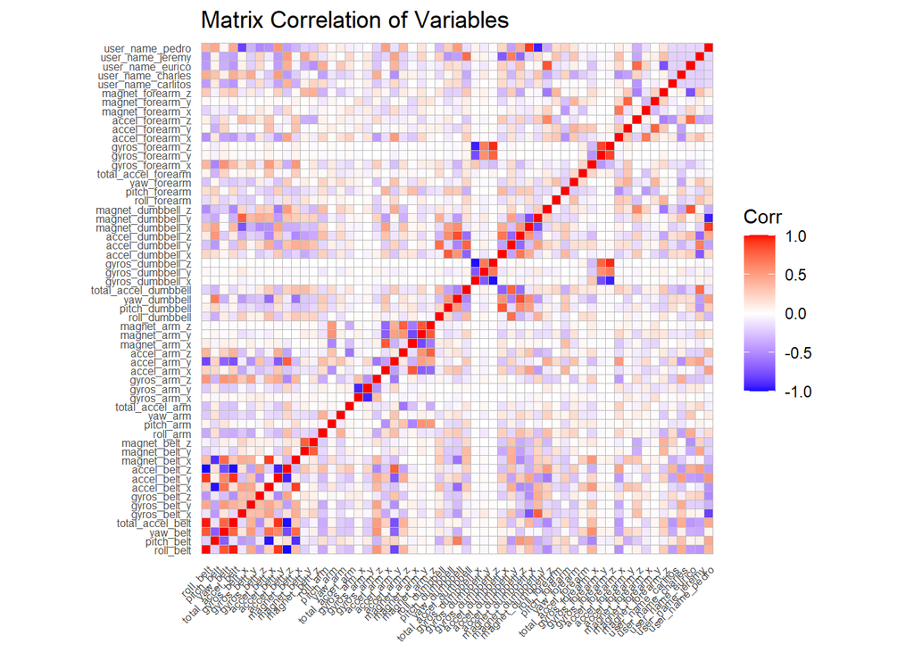

```r
#correl_matrix[lower.tri(correl_matrix)] <- NA
ggcorrplot(correl_matrix,title = "Matrix Correlation of Variables", tl.cex = 6)
```

```r
correl_matrix2 <- cor(pml_num[,-high_correl])                                 # build correlation matrix
dim(correl_matrix2)
```

```
## [1] 42 42
```

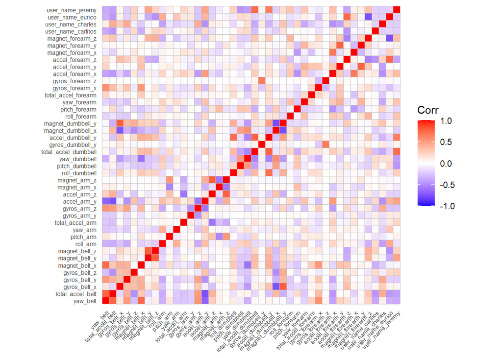

```r
#correl_matrix2[lower.tri(correl_matrix2)] <- NA
ggcorrplot(correl_matrix2, tl.cex = 6)
```

## References

[Ugulino, W.](http://web.archive.org/web/20161224072740/http:/groupware.les.inf.puc-rio.br/collaborator.jsf?p1=ugulino); [Cardador, D.](http://web.archive.org/web/20161224072740/http:/groupware.les.inf.puc-rio.br/collaborator.jsf?p1=debora); [Vega, K.](http://web.archive.org/web/20161224072740/http:/groupware.les.inf.puc-rio.br/collaborator.jsf?p1=katia); [Velloso, E.](http://web.archive.org/web/20161224072740/http:/groupware.les.inf.puc-rio.br/collaborator.jsf?p1=evelloso); Milidiu, R.; [Fuks, H.](http://web.archive.org/web/20161224072740/http:/groupware.les.inf.puc-rio.br/collaborator.jsf?p1=hugo) [**Wearable Computing: Accelerometers’ Data Classification of Body Postures and Movements**](http://web.archive.org/web/20161224072740/http:/groupware.les.inf.puc-rio.br/work.jsf?p1=10335). Proceedings of 21st Brazilian Symposium on Artificial Intelligence. Advances in Artificial Intelligence - SBIA 2012. In: Lecture Notes in Computer Science. , pp. 52-61. Curitiba, PR: Springer Berlin / Heidelberg, 2012. ISBN 978-3-642-34458-9. DOI: 10.1007/978-3-642-34459-6_6. Cited by 2 (Google Scholar)

Read more: http:/groupware.les.inf.puc-rio.br/har#ixzz4TjpmNgaJ